# Actividad - Proyecto práctico

> La actividad se desarrollará en grupos pre-definidos de 4 alumnos. Se debe indicar los nombres en orden alfabético (de apellidos). Recordad que esta actividad se corresponde con un 30% de la nota final de la asignatura. Se debe entregar entregar el trabajo en la presente notebook.
- Alumno 1: Julián David Gamboa García
- Alumno 2: Daniel Enrique Guzmán Reyes
- Alumno 3: Kevin Omar Soto Simanca

## **PARTE 1** - Instalación y requisitos previos

> Las prácticas han sido preparadas para poder realizarse en el entorno de trabajo de Google Colab. Sin embargo, esta plataforma presenta ciertas incompatibilidades a la hora de visualizar la renderización en gym. Por ello, para obtener estas visualizaciones, se deberá trasladar el entorno de trabajo a local. Por ello, el presente dosier presenta instrucciones para poder trabajar en ambos entornos. Siga los siguientes pasos para un correcto funcionamiento:
1. **LOCAL:** Preparar el enviroment, siguiendo las intrucciones detalladas en la sección *1.1.Preparar enviroment*.
2. **AMBOS:** Modificar las variables "mount" y "drive_mount" a la carpeta de trabajo en drive en el caso de estar en Colab, y ejecturar la celda *1.2.Localizar entorno de trabajo*.
3. **COLAB:** se deberá ejecutar las celdas correspondientes al montaje de la carpeta de trabajo en Drive. Esta corresponde a la sección *1.3.Montar carpeta de datos local*.
4. **AMBOS:** Instalar las librerías necesarias, siguiendo la sección *1.4.Instalar librerías necesarias*.

### 1.1. Preparar enviroment (solo local)

1. En Windows, puede ser necesario instalar las C++ Build Tools. Para ello, siga los siguientes pasos. Alternativamente puedes utilizar WSL2: https://towardsdatascience.com/how-to-install-openai-gym-in-a-windows-environment-338969e24d30.
2. Instalar Anaconda
3. Siguiendo el código que se presenta comentado en la próxima celda: Crear un enviroment, cambiar la ruta de trabajo, e instalar librerías básicas.

> Para preparar el entorno de trabajo en local, se han seguido los siguientes pasos:

```
conda create --name miar_rl python=3.8
conda activate miar_rl
cd "PATH_TO_FOLDER"
conda install git
pip install jupyter
```

4. Abrir la notebook con *jupyter-notebook*.

```
jupyter-notebook
```

### 1.2. Localizar entorno de trabajo: Google colab o local

```python
# ATENCIÓN!! Modificar ruta relativa a la práctica si es distinta (drive_root)
import os

mount=''
drive_root = ''
IN_COLAB = False

drive_root = r"C:\Users\kevin\Downloads\ESTUDIO MASTER EN IA\Aprendizaje por refuerzo\PROYECTO\Proyecto RL"

os.makedirs(drive_root, exist_ok=True)
os.chdir(drive_root)

print("IN_COLAB:", IN_COLAB)
print("Carpeta de trabajo:", os.getcwd())

try:
  from google.colab import drive
  IN_COLAB=True
except:
  IN_COLAB=False
```

```
IN_COLAB: False
Carpeta de trabajo: C:\Users\kevin\Downloads\ESTUDIO MASTER EN IA\Aprendizaje por refuerzo\PROYECTO\Proyecto RL
```

### 1.3. Montar carpeta de datos local (solo Colab)

```python
# Switch to the directory on the Google Drive that you want to use
import os
if IN_COLAB:
  print("We're running Colab")

  if IN_COLAB:
    # Mount the Google Drive at mount
    print("Colab: mounting Google drive on ", mount)

    drive.mount(mount)

    # Create drive_root if it doesn't exist
    create_drive_root = True
    if create_drive_root:
      print("\nColab: making sure ", drive_root, " exists.")
      os.makedirs(drive_root, exist_ok=True)

    # Change to the directory
    print("\nColab: Changing directory to ", drive_root)
    %cd $drive_root
# Verify we're in the correct working directory
%pwd
print("Archivos en el directorio: ")
print(os.listdir())
```

```
Archivos en el directorio:
['.ipynb_checkpoints', 'checkpoint', 'dqn_Acrobot-v1_p1_best.h5f.data-00000-of-00001', 'dqn_Acrobot-v1_p1_best.h5f.index', 'dqn_Acrobot-v1_p1_best_score.txt', 'dqn_Acrobot-v1_p1_log.json', 'dqn_Acrobot-v1_p1_weights.h5f.data-00000-of-00001', 'dqn_Acrobot-v1_p1_weights.h5f.index', 'dqn_Acrobot-v1_p1_…
```

### 1.4. Instalar librerías necesarias

```python
if IN_COLAB:
  # Downgrade to TF 2.15 to ensure Keras 2 compatibility for keras-rl2
  %pip install tensorflow==2.15.0
  %pip install numpy==1.26.4
  %pip install keras==2.15.0
  %pip install gym==0.17.3
  %pip install keras-rl2==1.0.5
else:
  %pip install tensorflow==2.15.0
  %pip install numpy==1.26.4
  %pip install keras==2.15.0
  %pip install gym==0.17.3
  %pip install keras-rl2==1.0.5
```

[output not shown]

## **PARTE 2**. Enunciado

Consideraciones a tener en cuenta:

- El entorno sobre el que trabajaremos será el indicado en el listado correspondien de cada grupo y el algoritmo que usaremos será *DQN*.
- Para nuestro ejercicio, el requisito mínimo será alcanzado cuando el agente consiga una **media de recompensa por encima de los puntos indicados en el listado por grupos en modo test**. Por ello, esta media de la recompensa se calculará a partir del código de test en la última celda del notebook.

Este proyecto práctico consta de tres partes:

1. Implementar la red neuronal que se usará en la solución
2. Implementar las distintas piezas de la solución DQN y probar al menos 3 propuestas diferentes de mejora.
3. Justificar la respuesta en relación a los resultados obtenidos e incluir al menos 3 gráficas relevantes comparando las 3 propuestas.

**Rúbrica**: Se valorará la originalidad en la solución aportada, así como la capacidad de discutir los resultados de forma detallada. El requisito mínimo servirá para aprobar la actividad, bajo premisa de que la discusión del resultado sera apropiada.

IMPORTANTE:

- Si no se consigue una puntuación óptima, responder sobre la mejor puntuación obtenida.
- Para entrenamientos largos, recordad que podéis usar checkpoints de vuestros modelos para retomar los entrenamientos. En este caso, recordad cambiar los parámetros adecuadamente (sobre todo los relacionados con el proceso de exploración).
- Se deberá entregar unicamente el notebook y los pesos del mejor modelo en un fichero .zip, de forma organizada.
- Cada alumno deberá de subir la solución de forma individual.

## **PARTE 3**. Desarrollo y preguntas

### Funcionamiento del Entorno: Acrobot-v1

Físicamente, se trata de un sistema conocido como péndulo doble subactuado.

1. La Física del Juego (Mecánica)

El robot está compuesto por dos segmentos (eslabones) conectados por dos articulaciones:

- El Hombro: Está fijo en una posición central y gira libremente respondiendo a la inercia y la gravedad.
- El Codo: Es la unión entre el primer y el segundo brazo. Esta es la única articulación motorizada que el agente puede controlar.
2. Sistema de Puntuación (Ganar y Perder)

Acrobot es un desafío de optimización de tiempo. No ganas puntos por hacer piruetas; el objetivo es salir del estado inicial lo más rápido posible.

**¿Cómo se gana?**

En la parte superior del entorno existe una línea horizontal objetivo. El episodio se considera superado en el instante exacto en que la punta inferior del segundo brazo logra cruzar por encima de esa línea gracias al balanceo.

**El Castigo y la Puntuación**

Penalización continua: El agente recibe una recompensa estricta de -1 punto por cada paso de tiempo que transcurre sin haber cruzado la meta.

**¿Cómo se pierde?**: El juego tiene un límite de 500 pasos máximos por episodio. Si el agente no logra cruzar la meta al llegar al paso 500, el entorno detiene la simulación automáticamente.

Interpretación del puntaje: Debido a los números negativos, un valor más cercano a cero es un mejor resultado.

Puntuación de -500: El agente fracasó y se agotó el tiempo.

Puntuación de -75: Excelente desempeño; el agente aprendió la técnica para generar impulso y cruzó la meta en tan solo 75 movimientos rápidos.

#### Importar librerías

```python
os.environ['TF_USE_LEGACY_KERAS']="1"
```

```python
#Comprobamos que se carga la versión esperada de TF y detecta la GPU
import tensorflow as tf1
print(tf1.__version__)
print(tf1.config.list_physical_devices('GPU'))
print(tf1.config.list_logical_devices('GPU'))
```

```
2.5.3
[]
[]
```

```python
import tensorflow.keras as tf
from keras import __version__
tf.__version__ = __version__

print(tf.__version__)
```

```
2.5.0
```

```python
from __future__ import division

import numpy as np
import gym

from tensorflow.keras.models import Sequential
from tensorflow.keras.layers import Dense, Activation, Flatten, Permute

if IN_COLAB:
  from tensorflow.keras.optimizers.legacy import Adam
else:
  from tensorflow.keras.optimizers import Adam

import tensorflow.keras.backend as K

from rl.agents.dqn import DQNAgent
from rl.policy import LinearAnnealedPolicy, BoltzmannQPolicy, EpsGreedyQPolicy
from rl.memory import SequentialMemory
from rl.core import Processor
from rl.callbacks import FileLogger, ModelIntervalCheckpoint
```

#### Configuración base

```python
#Descomentar y adaptar a cada entorno según corresponda

WINDOW_LENGTH = 1
#
env_name = 'Acrobot-v1'
env = gym.make(env_name)

np.random.seed(123)
env.seed(123)
nb_actions = env.action_space.n
```

```python
class AcrobotProcessor(Processor):
    def process_observation(self, observation):
        # Acrobot devuelve un vector 1D de 6 valores.
        # Simplemente nos aseguramos de que sea un array de tipo float32.
        return np.array(observation, dtype='float32')

    def process_state_batch(self, batch):
        # Devolvemos el batch tal cual. ¡NO dividimos por 255!
        return batch

    def process_reward(self, reward):
        # Acrobot otorga una recompensa de -1 por cada paso que no llega a la meta,
        # y 0 cuando llega. No necesitamos recortar las recompensas.
        return reward
```

Arquitectura de la Red Neuronal

El "cerebro" del agente se construyó utilizando un Perceptrón Multicapa (MLP) a través de la API Sequential de Keras. Su objetivo es mapear el estado actual del entorno hacia el valor Q (recompensa futura esperada) de cada acción posible.

1. Capa de Entrada (Flatten): El entorno Acrobot devuelve un vector de observación de 6 variables continuas. Dado que keras-rl2 utiliza una ventana de tiempo (window_length=1), los datos ingresan con una forma de (1, 6). La capa Flatten es indispensable para aplanar esta matriz a un vector 1D que las capas densas puedan procesar.
2. Capas Ocultas (Dense): Se implementaron 3 capas ocultas de 64 neuronas cada una.

Justificación: El entorno de Acrobot tiene dinámicas no lineales complejas (física de péndulos interactuando). Tres capas de 64 nodos ofrecen la profundidad matemática suficiente para extraer estas características sin caer en un sobreajuste (overfitting) o hacer el entrenamiento excesivamente lento.

Activación (ReLU): Se utilizó la función de activación Rectified Linear Unit. Es el estándar en redes profundas porque evita el problema de la desaparición del gradiente, permitiendo que la red aprenda más rápido.

3. Capa de Salida (Dense): Consta de 3 neuronas (una para cada acción: fuerza izquierda, inercia, fuerza derecha).

Activación (Linear): A diferencia de los problemas de clasificación que usan Softmax (para dar probabilidades del 0 al 1), aquí usamos activación lineal pura. Esto se debe a que el modelo debe predecir Valores Q, los cuales son estimaciones de puntuaciones que pueden ser números negativos grandes (ej. -85.5).

```python
from tensorflow.keras.models import Sequential
from tensorflow.keras.layers import Dense, Flatten

# 1. Obtenemos las dimensiones correctas del entorno
obs_shape = env.observation_space.shape
nb_actions = env.action_space.n

# 2. Construimos la red con el input_shape explícito
model = Sequential()
# Usamos (1,) + obs_shape para que coincida con el formato de keras-rl2
model.add(Flatten(input_shape=(1,) + obs_shape))
model.add(Dense(64, activation='relu'))
model.add(Dense(64, activation='relu'))
model.add(Dense(64, activation='relu'))
model.add(Dense(nb_actions, activation='linear'))

# Verifica la arquitectura (opcional, pero recomendado)
model.summary()
```

```
Model: "sequential"
_________________________________________________________________
Layer (type)                 Output Shape              Param #
=================================================================
flatten (Flatten)            (None, 6)                 0
_________________________________________________________________
dense (Dense)                (None, 64)                448
_________________________________________________________________
dense_1 (Dense)              (None, 64)                4160
_________________________________________________________________
dense_2 (Dense)              (None, 64)                4160
_________________________________________________________________
dense_3 (Dense)              (None, 3)                 195
=================================================================
Total params: 8,963
Trainable params: 8,963
Non-trainable params: 0
_________________________________________________________________
```

2. Implementación de la solución DQN

Lógica del Agente (Parámetros DQN)

El agente DQNAgent coordina el entrenamiento. Sus hiperparámetros fueron seleccionados para garantizar estabilidad:

Memoria de Experiencia (SequentialMemory): Capacidad de 50,000 transiciones.

Justificación: En lugar de aprender del último fotograma (lo cual generaría sesgos temporales porque un fotograma se parece mucho al anterior), el agente guarda sus experiencias y toma "lotes aleatorios" del pasado para aprender. Esto estabiliza drásticamente el entrenamiento.

Política de Exploración (LinearAnnealedPolicy + EpsGreedyQPolicy):

Factor de Descuento (gamma = 0.99):

Justificación: Al ser muy cercano a 1, el agente prioriza altamente las recompensas a largo plazo (llegar a la meta) por encima de las recompensas inmediatas. Es crucial en Acrobot, donde el éxito requiere planeación de varios pasos (balancearse varias veces antes de subir).

Actualización de la Red Objetivo (target_model_update = 10000):

Justificación: DQN utiliza dos redes (una principal que aprende y una objetivo que guía). Si el "objetivo" se mueve constantemente, el agente nunca converge. Congelar la red objetivo y actualizarla solo cada 10,000 pasos proporciona un blanco fijo y estable para el aprendizaje.

```python
memory = SequentialMemory(limit=50000, window_length=WINDOW_LENGTH)
processor = AcrobotProcessor()
```

```python
policy = LinearAnnealedPolicy(EpsGreedyQPolicy(), attr='eps',
                              value_max=0.01, value_min=.05, value_test=.05,
                              nb_steps=30000)
```

```python
dqn_1 = DQNAgent(model=model, nb_actions=nb_actions, policy=policy,
                 memory=memory, processor=processor,
                 nb_steps_warmup=1000, gamma=.99,
                 target_model_update=10000,
                 train_interval=4)
dqn_1.compile(Adam(learning_rate=1e-4), metrics=['mae'])
```

```python
from tensorflow.keras.callbacks import Callback
# ==========================================
# 4. CALLBACK CON MEMORIA PERSISTENTE
# ==========================================
class SaveBestModel(Callback):
    def __init__(self, filepath):
        super(SaveBestModel, self).__init__()
        self.filepath = filepath
        # Creamos la ruta para el archivo de texto que guardará el puntaje
        self.score_path = filepath.replace('.h5f', '_score.txt')

        # LÓGICA DE REANUDACIÓN DE PUNTAJE
        if os.path.exists(self.score_path):
            with open(self.score_path, 'r') as f:
                self.best_mean_reward = float(f.read())
            print(f"📈 [Memoria] Récord histórico detectado en local. Umbral a superar: {self.best_mean_reward:.2f}")
        else:
            self.best_mean_reward = -500.0
            print("🆕 [Memoria] Primer entrenamiento. Umbral inicial: -500.00")

        self.reward_history = deque(maxlen=20)

    def on_episode_end(self, episode, logs={}):
        self.reward_history.append(logs.get('episode_reward', -500.0))

        if len(self.reward_history) == 20:
            mean_reward = np.mean(self.reward_history)

            if mean_reward > self.best_mean_reward:
                self.best_mean_reward = mean_reward

                # 1. Guardamos los pesos matemáticos
                self.model.save_weights(self.filepath, overwrite=True)

                # 2. Guardamos el nuevo récord en el archivo de texto
                with open(self.score_path, 'w') as f:
                    f.write(str(mean_reward))

                print(f"\n[🏆] ¡Récord superado! Nuevo mejor cerebro guardado con media: {mean_reward:.2f}")
```

```python
import glob
import os
import json
from collections import deque

# 1. Definimos de qué propuesta se trata para aislar sus archivos
propuesta_id = 'p1'
best_weights_path = os.path.join(drive_root, f'dqn_{env_name}_{propuesta_id}_best.h5f')

# 2. Asignamos nombres únicos a los pesos, checkpoints y logs
weights_filename = os.path.join(drive_root, f'dqn_{env_name}_{propuesta_id}_weights.h5f')
checkpoint_weights_filename = os.path.join(drive_root, f'dqn_{env_name}_{propuesta_id}_weights_{{step}}.h5f')
log_filename = os.path.join(drive_root, f'dqn_{env_name}_{propuesta_id}_log.json')

# 3. LÓGICA DE AUTO-REANUDACIÓN SEGURA
# Ahora el patrón de búsqueda solo filtrará los checkpoints de ESTA propuesta
search_pattern = os.path.join(drive_root, f'dqn_{env_name}_{propuesta_id}_weights_*.h5f.index')
checkpoints = glob.glob(search_pattern)

if checkpoints:
    # Obtenemos el más reciente por fecha de modificación
    latest_checkpoint_index = sorted(checkpoints, key=os.path.getmtime)[-1]
    base_weights_path = latest_checkpoint_index.replace(".index", "")
    print(f"Checkpoint de la {propuesta_id} detectado en local: {base_weights_path}")

    try:
        # ATENCIÓN: Asegúrate de usar la variable correcta de tu agente (ej: dqn_1, dqn_2)
        dqn_1.load_weights(base_weights_path)
        print("¡Pesos cargados correctamente! Reanudando entrenamiento...")
    except Exception as e:
        print(f"Error al cargar pesos: {e}. Se empezará desde cero.")
else:
    print(f"No se encontraron checkpoints previos para la {propuesta_id}. Iniciando desde cero.")


callbacks_1 = [ModelIntervalCheckpoint(checkpoint_weights_filename, interval=10000)]
callbacks_1 += [FileLogger(log_filename, interval=100)]
best_model_path = os.path.join(drive_root, f'dqn_{env_name}_{propuesta_id}_best.h5f')
# 4. Configuración de Callbacks y Entrenamiento
if os.path.exists(best_weights_path + ".index"):
    print(f"Cargando pesos matemáticos previos desde: {best_weights_path}")
    dqn_1.load_weights(best_weights_path)
callbacks_1 += [SaveBestModel(best_model_path)]
# (Recuerda añadir tu callback early_stop aquí si lo vas a usar)

dqn_1.fit(env, callbacks=callbacks_1, nb_steps=80000, log_interval=1000, visualize=False)
dqn_1.save_weights(weights_filename, overwrite=True)
```

```
No se encontraron checkpoints previos para la p1. Iniciando desde cero.
🆕 [Memoria] Primer entrenamiento. Umbral inicial: -500.00
Training for 80000 steps ...
Interval 1 (0 steps performed)
```

```
2 episodes - episode_reward: -500.000 [-500.000, -500.000]

Interval 2 (1000 steps performed)
4 episodes - episode_reward: -247.250 [-500.000, -119.000] - loss: 0.152 - mae: 0.566 - mean_q: -0.507 - mean_eps: 0.050

Interval 3 (2000 steps performed)
7 episodes - episode_reward: -125.143 [-149.000, -99.000] - loss: 0.014 - mae: 0.753 - mean_q: -0.925 - mean_eps: 0.050

Interval 4 (3000 steps performed)
[🏆] ¡Récord superado! Nuevo mejor cerebro guardado con media: -185.30
[🏆] ¡Récord superado! Nuevo mejor cerebro guardado con media: -174.05
8 episodes - episode_reward: -139.500 [-275.000, -96.000] - loss: 0.009 - mae: 0.755 - mean_q: -0.956 - mean_eps: 0.050

Interval 5 (4000 steps performed)
[🏆] ¡Récord superado! Nuevo mejor cerebro guardado con media: -160.30
2 episodes - episode_reward: -362.500 [-500.000, -225.000] - loss: 0.008 - mae: 0.762 - mean_q: -0.966 - mean_eps: 0.050

Interval 6 (5000 steps performed)
3 episodes - episode_reward: -330.333 [-447.000, -231.000] - loss: 0.007 - mae: 0.760 - mean_q: -0.968 - mean_eps: 0.050

Interval 7 (6000 steps performed)
3 episodes - episode_reward: -394.667 [-500.000, -303.000] - loss: 0.005 - mae: 0.725 - mean_q: -0.966 - mean_eps: 0.050

Interval 8 (7000 steps performed)
2 episodes - episode_reward: -392.500 [-415.000, -370.000] - loss: 0.003 - mae: 0.713 - mean_q: -0.974 - mean_eps: 0.050

Interval 9 (8000 steps performed)
2 episodes - episode_reward: -464.500 [-500.000, -429.000] - loss: 0.003 - mae: 0.710 - mean_q: -0.983 - mean_eps: 0.050

Interval 10 (9000 steps performed)
3 episodes - episode_reward: -350.667 [-500.000, -257.000] - loss: 0.002 - mae: 0.704 - mean_q: -0.984 - mean_eps: 0.050

Interval 11 (10000 steps performed)
4 episodes - episode_reward: -306.750 [-500.000, -89.000] - loss: 0.031 - mae: 1.355 - mean_q: -1.886 - mean_eps: 0.050

Interval 12 (11000 steps performed)
2 episodes - episode_reward: -500.000 [-500.000, -500.000] - loss: 0.006 - mae: 1.356 - mean_q: -1.952 - mean_eps: 0.050

Interval 13 (12000 steps performed)
2 episodes - episode_reward: -500.000 [-500.000, -500.000] - loss: 0.004 - mae: 1.350 - mean_q: -1.953 - mean_eps: 0.050
```

[output cut: 186 more lines]

```

Interval 76 (75000 steps performed)
2 episodes - episode_reward: -500.000 [-500.000, -500.000] - loss: 0.061 - mae: 5.075 - mean_q: -7.517 - mean_eps: 0.111

Interval 77 (76000 steps performed)
2 episodes - episode_reward: -500.000 [-500.000, -500.000] - loss: 0.049 - mae: 5.080 - mean_q: -7.529 - mean_eps: 0.112

Interval 78 (77000 steps performed)
2 episodes - episode_reward: -500.000 [-500.000, -500.000] - loss: 0.062 - mae: 5.078 - mean_q: -7.520 - mean_eps: 0.113

Interval 79 (78000 steps performed)
2 episodes - episode_reward: -471.000 [-500.000, -442.000] - loss: 0.055 - mae: 5.079 - mean_q: -7.527 - mean_eps: 0.115

Interval 80 (79000 steps performed)
done, took 158.223 seconds
```

```python
import numpy as np
import pandas as pd
from rl.policy import EpsGreedyQPolicy

# 1. Le decimos a tu agente original que use 1% de exploración en el test
# dqn_1.test_policy = EpsGreedyQPolicy(eps=0.01)
propuesta_id = 'p1'
best_weights_path = os.path.join(drive_root, f'dqn_{env_name}_{propuesta_id}_best.h5f')

print(f"🧠 Intentando cargar el cerebro maestro en dqn_1 desde:\n{best_weights_path}\n")

try:
    # 2. Inyectamos los pesos en el agente original
    dqn_1.load_weights(best_weights_path)
    print("✅ ¡Carga exitosa! El agente dqn_1 ha recuperado su nivel experto.")

    # 3. Ejecutamos la evaluación en silencio
    print("\nIniciando evaluación de 100 episodios... ¡Paciencia!")
    history = dqn_1.test(env, nb_episodes=100, visualize=False, verbose=0)

    # 4. Resultados reales
    test_rewards = history.history['episode_reward']
    mean_reward = np.mean(history.history['episode_reward'])
    print("\n" + "⭐"*20)
    print(f"🏆 MEDIA FINAL DE TU PROYECTO: {mean_reward:.2f}")
    print("⭐"*20)

except Exception as e:
    # Si falla, esta vez sí imprimirá el error exacto en rojo para que sepamos qué es
    print("\n❌ ERROR REAL AL CARGAR EL ARCHIVO:")
    print(e)
```

```
🧠 Intentando cargar el cerebro maestro en dqn_1 desde:
C:\Users\kevin\Downloads\ESTUDIO MASTER EN IA\Aprendizaje por refuerzo\PROYECTO\Proyecto RL\dqn_Acrobot-v1_p1_best.h5f

✅ ¡Carga exitosa! El agente dqn_1 ha recuperado su nivel experto.

Iniciando evaluación de 100 episodios... ¡Paciencia!

⭐⭐⭐⭐⭐⭐⭐⭐⭐⭐⭐⭐⭐⭐⭐⭐⭐⭐⭐⭐
🏆 MEDIA FINAL DE TU PROYECTO: -316.49
⭐⭐⭐⭐⭐⭐⭐⭐⭐⭐⭐⭐⭐⭐⭐⭐⭐⭐⭐⭐
```

```python
exitos_base = sum(1 for r in test_rewards if r > -500)
total_base = len(test_rewards)

print(f"Tasa de éxito: {exitos_base/total_base*100:.1f}%")
print(f"Mejor episodio: {max(test_rewards)}")
print(f"Peor episodio: {min(test_rewards)}")
```

```
Tasa de éxito: 88.0%
Mejor episodio: -146.0
Peor episodio: -500.0
```

```python
!pip install pyvirtualdisplay
```

```python
import shutil

ruta_ffmpeg = r"C:\Users\kevin\anaconda3\envs\miar_rl\Library\bin"

os.environ["PATH"] = ruta_ffmpeg + os.pathsep + os.environ["PATH"]

print("ffmpeg detectado:", shutil.which("ffmpeg"))
```

```
ffmpeg detectado: C:\Users\kevin\anaconda3\envs\miar_rl\Library\bin\ffmpeg.EXE
```

```python
import gym
from gym.wrappers import Monitor
from rl.policy import EpsGreedyQPolicy

# ==========================================
# 1. PREPARAR LA CÁMARA
# ==========================================
# Creamos un entorno fresco exclusivo para el video
env_video = gym.make('Acrobot-v1')
carpeta_videos = './videos_proyecto'
env_video = Monitor(env_video, carpeta_videos, force=True, video_callable=lambda episode_id: True)

# ==========================================
# 2. PREPARAR AL AGENTE QUE YA TIENES EN MEMORIA
# ==========================================
# Le quitamos la aleatoriedad para que use lo que ya aprendió
dqn_1.test_policy = EpsGreedyQPolicy(eps=0.0)

# ==========================================
# 3. ¡GRABACIÓN SILENCIOSA!
# ==========================================
print(f"🎬 Grabando 3 episodios... (Renderizando en segundo plano)")

# IMPORTANTE: visualize=False es obligatorio en WSL
dqn_1.test(env_video, nb_episodes=3, visualize=False, verbose=1)

# ==========================================
# 4. APAGAR Y GUARDAR
# ==========================================
env_video.close()

print("\n✅ ¡Corte! Video guardado exitosamente en la carpeta 'videos_proyecto'.")
```

```
🎬 Grabando 3 episodios... (Renderizando en segundo plano)
Testing for 3 episodes ...
Episode 1: reward: -294.000, steps: 295
Episode 2: reward: -279.000, steps: 280
Episode 3: reward: -278.000, steps: 279

✅ ¡Corte! Video guardado exitosamente en la carpeta 'videos_proyecto'.
```

```python
## 3.1. Cargar log de entrenamiento
log_path = os.path.join(drive_root, f'dqn_{env_name}_{propuesta_id}_log.json')

with open(log_path, 'r') as f:
    log_data = json.load(f)

episode_reward = log_data['episode_reward']
nb_episode_steps = log_data['nb_episode_steps']
nb_steps = log_data['nb_steps']

print("Número de episodios registrados:", len(episode_reward))
print("Último paso registrado:", nb_steps[-1])
print("Recompensa media entrenamiento:", np.mean(episode_reward))
print("Mejor recompensa:", np.max(episode_reward))
print("Peor recompensa:", np.min(episode_reward))
```

```
Número de episodios registrados: 197
Último paso registrado: 79844
Recompensa media entrenamiento: -404.83756345177665
Mejor recompensa: -89.0
Peor recompensa: -500.0
```

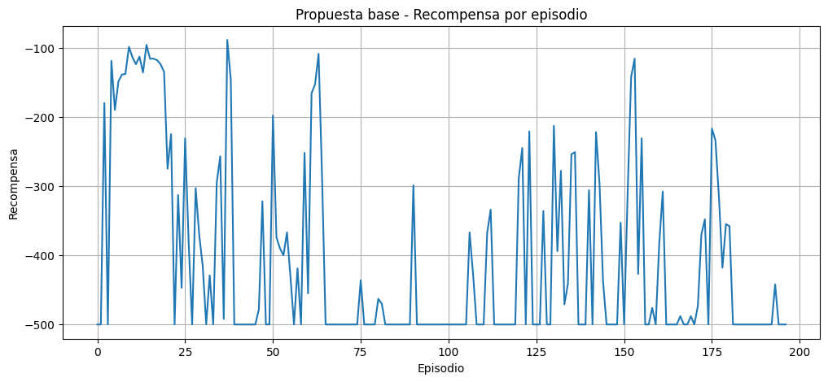

```python
#3.2. Gráfica 1 — Recompensa por episodio
import matplotlib.pyplot as plt

plt.figure(figsize=(12, 5))
plt.plot(episode_reward)
plt.title('Propuesta base - Recompensa por episodio')
plt.xlabel('Episodio')
plt.ylabel('Recompensa')
plt.grid(True)
plt.show()
```

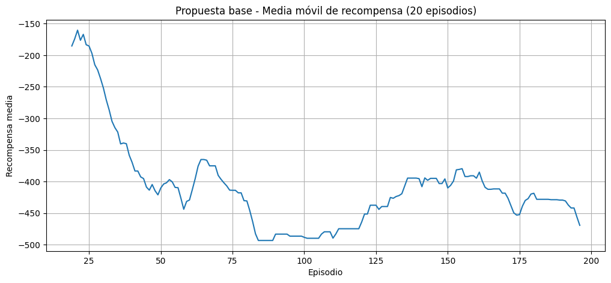

```python
# 3.3. Gráfica 2 — Media móvil de recompensa
window = 20
moving_avg_reward = pd.Series(episode_reward).rolling(window).mean()

plt.figure(figsize=(12, 5))
plt.plot(moving_avg_reward)
plt.title(f'Propuesta base - Media móvil de recompensa ({window} episodios)')
plt.xlabel('Episodio')
plt.ylabel('Recompensa media')
plt.grid(True)
plt.show()
```

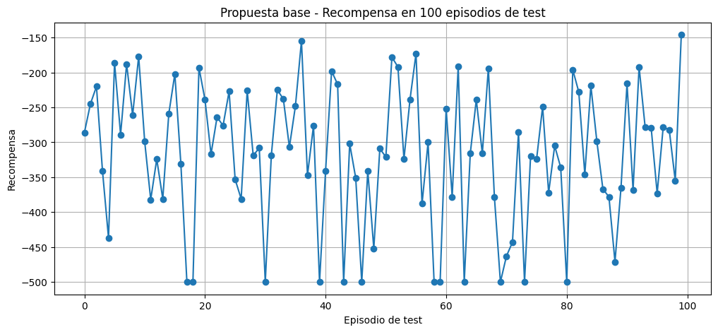

```python
plt.figure(figsize=(12, 5))
plt.plot(test_rewards, marker='o')
plt.title('Propuesta base - Recompensa en 100 episodios de test')
plt.xlabel('Episodio de test')
plt.ylabel('Recompensa')
plt.grid(True)
plt.show()
```